# The Replication Crisis

And what to do about it

Author

Affiliation

Daniela Palleschi

Humboldt-Universität zu Berlin

Published

April 23, 2024

# Learning Objectives

Today we will learn about…

- the replication crisis
- replication in language sciences
- requirements for replication

# Resources

- this lecture covers Sönning & Werner (2021)
- introduction article of a special issue of the Journal *Linguistics*
  - *The replication crisis: Impications for linguistics*
- contains several articles on the topic, some of which we’ll read later

# Replication crisis

- data-based claims turned out to be less reliable than previously believed
  - statistical claims could not be replicated with new data
- large-scale replications brought attention to the issue
  - e.g., Nieuwland et al. (2018); Open Science Collaboration (2015)
- this has also led to distrust in findings in academia and the public

## Most Published Research Findings are False

- the issue became more widespread with Ioannidis (2005)
  - defined bias in terms of design, analysis, and presentation factors
  - focussed on issues with *p*-values and statistical power
- Open Science Collaboration (2015) ran replications of 100 studies
  - 36% of replications found significant effects
  - 47% of original effects fell within 95% CIs of replication effect
- in essence: fewer significant findings and smaller effects in replications
- how is can this be?

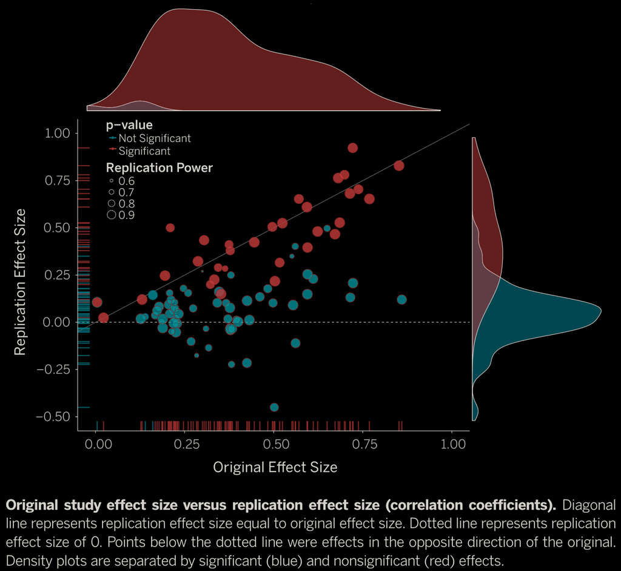

Figure 1: Source: Open Science Collaboration (2015) (all rights reserved)

## The problem with p-values

- issues relating to reported findings:
  - misuse of misinterpretation of p-values in Null Hypothesis Significant Testing (NHST; e.g., Ioannidis, 2005)
  - study design
  - improper use of statistical methods
    - stemming from inadequate teaching
  - selective reporting
- in other words, HARKing and p-hacking (whether consciously done or not)

## Solving the problem

- these could be mitigated with Open Science practices
  - *transparency* in writing, analyses, planning/hypothesising stages
  - *reproducibility* of analyses
  - greater value given to *replication* studies
  - embracing and addressing *uncertainty* (Vasishth & Gelman, 2021)
- in sum: “conscientious practice” (Sönning & Werner, 2021, p. 1182)

## The garden of forking paths

- or ‘researcher degrees of freedom’ (Simmons et al., 2011)
- the problem: there are many plausible ways to analyse any given data set
- there are many choices researchers make in:
  - experimental design
  - data collection
  - data preprocessing
  - data analyses
  - reporting
- the path we happen to go down can seem pre-determined (Gelman & Loken, 2014)
  - but can amount to HARKing, *p*-hacking, fishing
- the fastest solution: share everything and write transparently

# The current state of quantitative linguistics

- there is a trend towards empirical methods throughout linguistics
  - we should pay attention to methodological discussions in related fields
- we also find ourselves in a state of methdological crisis

## Kuhn’s structure of scientific revoluations

Three recurrent phases:

1. **normal science**
   - little controversy over theoretical underpinnings
   - researchers work on small problems within a theory
2. **crisis**
   - contradictions between theory and evidence
   - questioning of conventionally accepted theory
3. **revolution**
   - overthrowing of previous norms in favour of a new paradigm
   - leads to new normal science

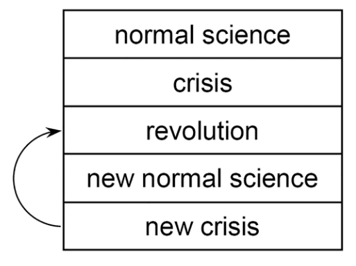

Download GitHub repositiory

## Previous cycles of statistical analyses

- proprietary, point-and-click software (e.g., SPSS)
  - move to open source programming languages (e.g., R, Python, Julia)
- ANOVAs
  - move to linear regression
  - then linear mixed models
    - random-intercepts only models
    - maximal models
    - parsimonious models
- now a trend towards Bayesian regression

## What do statisticians say?

- Wasserstein et al. (2019): list of Do’s and Don’t from statisticians
  - *Don’t* base conclusions on *p*-values
  - *Do* think about ATOM: Accept uncertainty, be Thoughtful, Open, and Modest
- Wasserstein & Lazar (2016): the American Statistical Association’s statement on *p*-values
  - *p*-values are often misused and misinterpreted
  - good statistical practice is part of good scientific practice
    - as such, relies on good study design and conduct
    - interpretation in context
    - complete and transparent reporting

# Overwhelmed?

- we’re in a state of crisis with a wealth of possible statistical paths
  - but no current “gold standard”
- this can lead to anxiety among researchers
  - which analysis should I run? am I doing it correctly?
- just keep in mind ATOM
  - strive for honesty, not perfection

# Revolution

- methodological anxiety stems from shifting sands, but leads to revolution
- revolution usually comes from young newcomers
  - resistance to change usually comes those with more invested in the prior ways
- the good news: the revolution is underway
  - leads to an increase in resources and courses on e.g., multi-level models
- one suggested reform: Open Science!

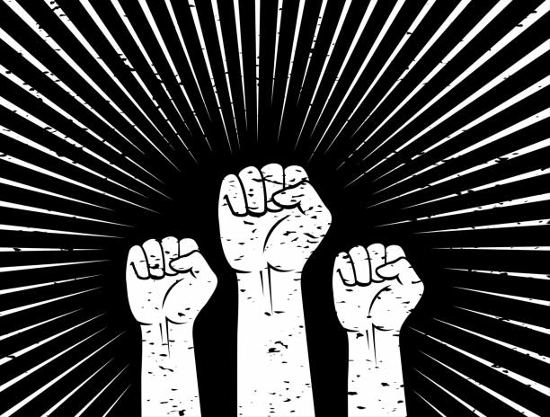

## The old vs. the new

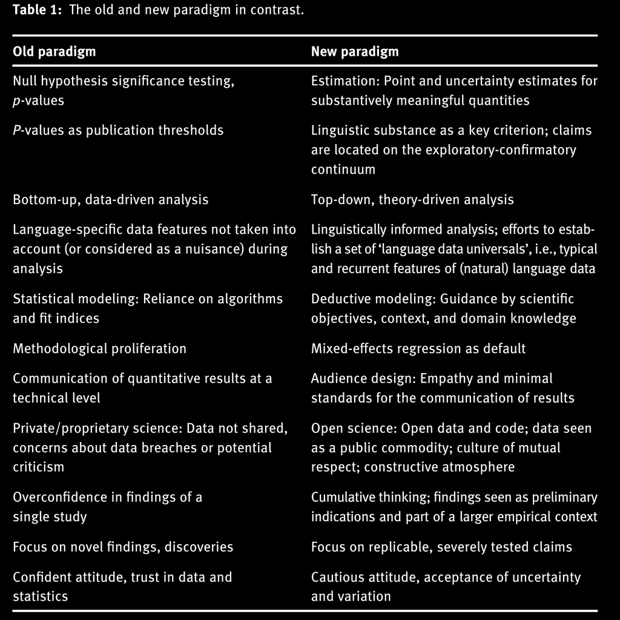

Figure 2: Source: Sönning & Werner (2021)

- changes refer to not only statistical analyses
  - but also emphasise transparency
- ideally, we (as a field) would up our analysis game
  - but a good first step is moving towards Open Science
  - share data, code
  - transparently map out your route in the ‘garden of forking paths’
- these are steps we’ll cover in this course
  - pre-registration
  - data and code sharing
  - reproducible workflow
  - transparent writing

# Simple fixes

- planning and design
  - large sample sizes
  - establish pre-processing/analysis steps a priori
- methodologically
  - select variables based on theory and research questions
  - model non-independence of data points (mixed models)
  - move towards estimation and away from arbitrary significance thresholds
- writing
  - be transparent about choices made

## Words of comfort

> Less experienced scholars must not fear methodological attacks on their analyses, which are instead seen as informing interim interpretations that may require future modification.

— Sönning & Werner (2021), p. 1199

- in some sub-fields linear mixed models are still not considered the standard
  - so you’re well situated despite the doom around *p*-values
- moving from frequentist (NHST) framework to the Bayesian framework is relatively painless
  - in this class we will run a LMM with `lme4` (Frequentist) and with `brms` (Bayesian)

# Running replications: what to replicate

- what makes a study ‘worth’ replicating?
  - suggestions from Isager (2020):
  1. value/interest of the topic
  2. uncertainty about the claim
  3. quality of proposed replication
     - or ability to reduce uncertainty
  4. costs and feasibility
- what makes a replication study ‘worthy’ for publication?
  - theoretical impact of the replicated finding
  - statistical power of the replication

## Replication value

- replication value (RV): “the expected utility of a finding before replication” (Isager, 2020, p. 6)
  - (scientific) value of the research claim
    - importance to the field, to policy, health etc.
  - the uncertainty of our knowledge about the claim
    - validity of study design, statistical power, bias, etc.
- replication aims to reduce uncertainty
  - which also increases utility of the claim

### Quantifying RV

- how to quantify *value* and *uncertainty*?
- Isager et al. (2021) suggest using…
  - average yearly citation count to estimate *value*
    - the more citations, the higher the impact the original study had
  - and sample size to estimate *uncertainty* ($\frac{1}{\sqrt{n}}$)
    - the higher the sample size, the more precise the estimate
    - the lower the sample size, the greater the uncertainty
    - i.e., $n$ is inversely correlated with *uncertainty*

## $RV_{Cn}$

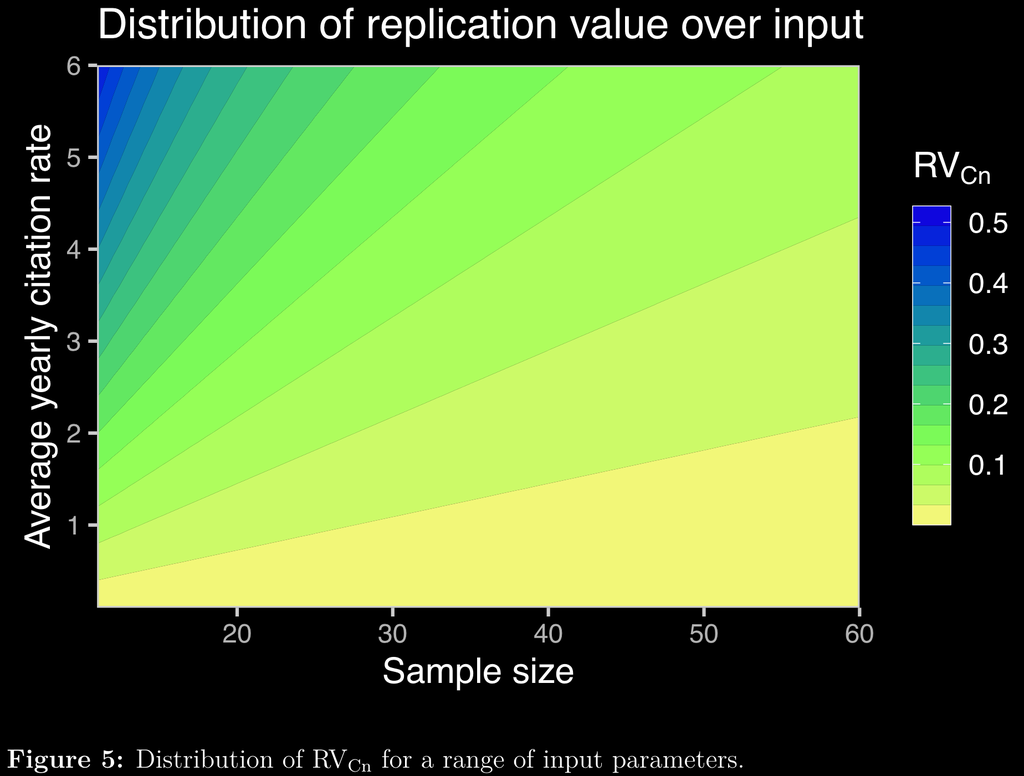

Figure 3: Source: Isager et al. (2021), p. 25 (all rights reserved)

Isager et al. (2021):

$$RV_{Cn} = value \ x \ uncertainty$$

# Student replications

> It is peculiar that undergraduate students can be taught about the perils of underpowered studies in formal statistical instruction and simultaneously be required to perform research that is almost inevitably underpowered

— Quintana (2021), p. 1117

- a possible solution: student thesis replications
  - hands-on experience in open science practices
  - e.g., cumulative replication studies run by multiple groups
- some resources for students interested in replications
  - Student Theses Replication Network Linguistics [(STReNeL)](https://blog.junge-sprachwissenschaft.de/2023/01/16/strenel.html)
  - Collaborative REplications and Education Project [(CREP)](https://osf.io/wfc6u/)
  - Framework for Open and Reproducible Research Training [(FORRT)](https://forrt.org/)
  - German Reproducibility Network [(DERN)](https://reproducibilitynetwork.de/)

# Exercise

- Moodle: Quiz ‘Kobrok & Roettger (2022)’
  - scan the article to answer the questions
  - this is not graded

# Learning objectives 🏁

Today we learned…

- the replication crisis ✅
- replication in language sciences ✅
- requirements for replication ✅

# References

Gelman, A., & Loken, E. (2014). The statistical crisis in science. *American Scientist*, *102*(6), 460–465.

Ioannidis, J. P. A. (2005). Why most published research findings are false. *PLoS Med*, *2*(8), 2–8. https://doi.org/10.1371/journal.pmed.0020124

Isager, P. M. (2020). *Deciding what to replicate: A formal definition of “replication value” and a decision model for replication study selection.* MetaArXiv. https://doi.org/10. 1037/met0000438

Isager, P. M., Van ’T Veer, A. E., & Lakens, D. (2021). *Replication value as a function of citation impact and sample size*. https://doi.org/10.31222/osf.io/knjea

Nieuwland, M. S., Politzer-Ahles, S., Heyselaar, E., Segaert, K., Darley, E., Kazanina, N., Von Grebmer Zu Wolfsthurn, S., Bartolozzi, F., Kogan, V., Ito, A., Mézière, D., Barr, D. J., Rousselet, G. A., Ferguson, H. J., Busch-Moreno, S., Fu, X., Tuomainen, J., Kulakova, E., Husband, E. M., … Huettig, F. (2018). Large-scale replication study reveals a limit on probabilistic prediction in language comprehension. *eLife*, *7*, e33468. https://doi.org/10.7554/eLife.33468

Open Science Collaboration. (2015). Estimating the reproducibility of psychological science. *Science*, *349*(6251), aac4716. https://doi.org/10.1126/science.aac4716

Quintana, D. S. (2021). Replication studies for undergraduate theses to improve science and education. *Nature Human Behaviour*, *5*(9), 1117–1118. https://doi.org/10.1038/s41562-021-01192-8

Simmons, J. P., Nelson, L. D., & Simonsohn, U. (2011). False-Positive Psychology: Undisclosed Flexibility in Data Collection and Analysis Allows Presenting Anything as Significant. *Psychological Science*, *22*(11), 1359–1366. https://doi.org/10.1177/0956797611417632

Sönning, L., & Werner, V. (2021). The replication crisis, scientific revolutions, and linguistics. *Linguistics*, *59*(5), 1179–1206. https://doi.org/10.1515/ling-2019-0045

Vasishth, S., & Gelman, A. (2021). How to embrace variation and accept uncertainty in linguistic and psycholinguistic data analysis. *Linguistics*, *59*(5), 1311–1342. https://doi.org/10.31234/osf.io/zcf8s

Wasserstein, R. L., & Lazar, N. A. (2016). The ASA Statement on *p* -Values: Context, Process, and Purpose. *The American Statistician*, *70*(2), 129–133. https://doi.org/10.1080/00031305.2016.1154108

Wasserstein, R. L., Schirm, A. L., & Lazar, N. A. (2019). Moving to a World Beyond “ *p* $<$ 0.05.” *The American Statistician*, *73*(sup1), 1–19. https://doi.org/10.1080/00031305.2019.1583913